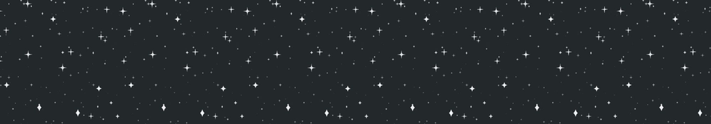

# IBM's Qiskit - Quantum Explorers 2023-2024

## Badge #6: Expert Navigator - Quantum Optimization

- **Story**
- **Instructions**
- **Quiz**
- **Unlock Your Badge**

## Story

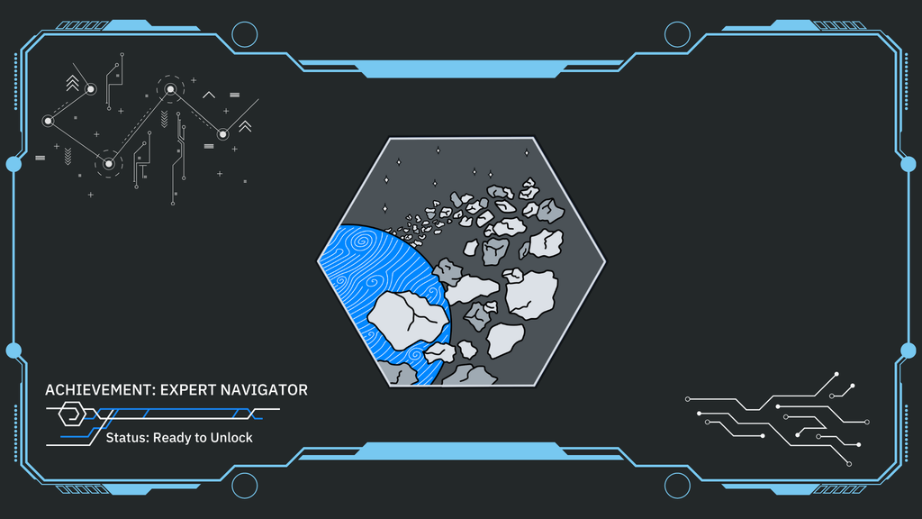

You want to explore a particular deep space region, but there’s an enormous asteroid field in your way. You decide to not let that deter you; turning back is not an option. Instead, you can perform optimization to identify the optimal path through the asteroid field to keep your crew safe. Remember, one wrong move means collision.

*(Share the wonders that await you to explore beyond the asteroid field in the* *[#space-exploration channel on Discord!](https://discord.com/channels/979714492533440533/1108653145116131338)** New planets? New cosmic phenomena waiting to be discovered? Get creative!)*

Complete this module to successfully navigate through the asteroid field, and become an Expert Navigator.

## Instructions

The Expert Navigator badge is a learning badge, which means this is a learning module.

### Tasks to complete to unlock this achievement

1. Go through the Expert Navigator syllabus at your own pace. The syllabus has study materials, labs, exercises, and resources.
   - The **[Expert Navigator badge workbook](https://ibm.box.com/v/qe23-navigator-56)** is a downloadable PDF that includes the syllabus, has interactable checkboxes, and note sections. You can use this to track your progress and take notes.
   - An **[online version of only the syllabus](https://learn.qiskit.org/syllabus/BMK-Q8E)** has been created for your convenience as well.
2. Once you think you're ready to unlock the badge, please take the quiz. You may attempt the quiz as many times as you like.

For any questions or discussions about the Expert Navigator badge and its material, please use the **[#q-optimization](https://discord.com/channels/979714492533440533/1100413012176806092)** channel on Discord.

**Important Links**

- **[Expert Navigator badge workbook](https://ibm.box.com/v/qe23-navigator-56)**
- **[Online version of the syllabus](https://learn.qiskit.org/syllabus/BMK-Q8E)**
- **[#q-optimization Discord channel](https://discord.com/channels/979714492533440533/1100413012176806092)**

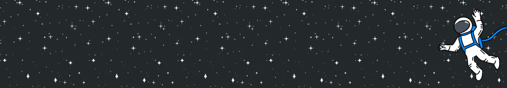

## Quiz

Ready to take the quiz?

For the multiple choice questions, choose the correct answer from the given list. There is only one correct answer. The answer must be a **list with an integer** denoting the option number. If you think all options are wrong, you can just pass an empty list.

For the coding question, please fill in the relevant Qiskit code as instructed.

### Scoring

- Multiple choice questions are worth 1 point each.
- The coding question is worth 3 points.
- Extra credit questions are worth 1 point each
- You must hit 12 points or more to pass.
- You will *not* be informed whether your answer is correct, except for the coding question.

Your score will be revealed at the end in the "Unlock Your Badge" section as a percentage. **Passing score is 80%.** Note: since there are extra credit questions, you may get over 100%!

Uncomment (remove the #) and run the code below if you are getting a "No module" error when attempting to grade your quiz answers.

```python
# update/upgrade Python's pip module
!pip install --upgrade pip -q

# install the IBM Qiskit's Machine Learning and Optimization modules
!pip install qiskit_machine_learning qiskit_optimization -q
```

**Question 1: Optimality is defined with respect to some criterion function, which is to be minimized or maximized. Which of the following is not what this criterion function is typically called?**

Choose the correct answer from the following list. There is only one correct answer.

1. Objective Function.
2. Boolean Function.
3. Cost Function.
4. Optimization Equation.

The answer must be a **list with an integer** denoting the option number. If you think all options are wrong, you can just pass an empty list.

```python
# build your code here
answer1 = [2]
```

```python
# run this cell to submit your answer

# import the grader for the exercise 1 of the lab/badge 6
from qc_grader.challenges.quantum_explorers23 import grade_badge6_ex1

# expected result type: List
grade_badge6_ex1(answer1)
```

```
Submitting your answer. Please wait...
Thank you for submitting your answer. Your answer has been recorded and, if correct, will count towards your final score.
```

**Question 2: Which answer best describes the definition of a combinatorial optimization problem?**

1. Problems where you search for the shortest length or value in an infinite set of potential solutions.
2. Combinatorial optimization problems are problems that use quantum computers to find a solution that gives you exponential speedup compared to the best classical algorithms.
3. The application of combinatorial optimization problems are limited to Finance and Chemistry.
4. Problems that search for an optimal solution in a finite or countably infinite set of potential solutions.

```python
# build your code here
answer2 = [4]
```

```python
# run this cell to submit your answer

# import the grader for the exercise 2 of the lab/badge 6
from qc_grader.challenges.quantum_explorers23 import grade_badge6_ex2

# expected result type: List
grade_badge6_ex2(answer2)
```

```
Submitting your answer. Please wait...
Thank you for submitting your answer. Your answer has been recorded and, if correct, will count towards your final score.
```

**Question 3: A Max-Cut Problem involves partitioning nodes of a graph into two sets, such that the number of edges between the sets is maximum. How many possible assignments are there for a graph with 4 nodes?**

1. 2.
2. 8.
3. 16.
4. 32.

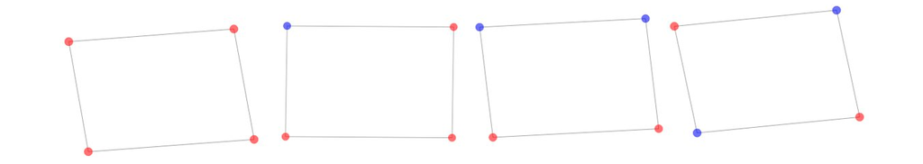

```python
# build your code here
answer3 = [3]
```

```python
# run this cell to submit your answer

# import the grader for the exercise 3 of the lab/badge 6
from qc_grader.challenges.quantum_explorers23 import grade_badge6_ex3

# expected result type: List
grade_badge6_ex3(answer3)
```

```
Submitting your answer. Please wait...
Thank you for submitting your answer. Your answer has been recorded and, if correct, will count towards your final score.
```

**Question 4: Which one of the following is not an essential aspect for defining an optimization problem?**

1. Objective Function.
2. Algorithms.
3. Decision Variables.
4. Constraints.

```python
# build your code here
answer4 = [2]
```

```python
# run this cell to submit your answer

# import the grader for the exercise 4 of the lab/badge 6
from qc_grader.challenges.quantum_explorers23 import grade_badge6_ex4

# expected result type: List
grade_badge6_ex4(answer4)
```

```
Submitting your answer. Please wait...
Thank you for submitting your answer. Your answer has been recorded and, if correct, will count towards your final score.
```

**Question 5: Which of the following does Qiskit Optimization not provide?**

1. Pre-defined application classes to create problems, easily.
2. High-level modeling of optimization problems.
3. A large example dataset that can be used to define various optimization problems.
4. Automatic conversion of problems to required representations (Ising Hamiltonian).

```python
# build your code here
answer5 = [3]
```

```python
# run this cell to submit your answer

# import the grader for the exercise 5 of the lab/badge 6
from qc_grader.challenges.quantum_explorers23 import grade_badge6_ex5

# expected result type: List
grade_badge6_ex5(answer5)
```

```
Submitting your answer. Please wait...
Thank you for submitting your answer. Your answer has been recorded and, if correct, will count towards your final score.
```

**Question 6: Which best describes an example of how to make a quadratic program from your maxcut problem statement using Qiskit?**

1. qp = maxcut.to_quadratic_program()
2. from qiskit_optimization.applications import Maxcut
3. maxcut.draw()
4. from qiskit_optimization.converters import QuadraticProgramToQubo

```python
# build your code here
answer6 = [1]
```

```python
# run this cell to submit your answer

# import the grader for the exercise 6 of the lab/badge 6
from qc_grader.challenges.quantum_explorers23 import grade_badge6_ex6

# expected result type: List
grade_badge6_ex6(answer6)
```

```
Submitting your answer. Please wait...
Thank you for submitting your answer. Your answer has been recorded and, if correct, will count towards your final score.
```

**Question 7: An exact algorithm guarantees the optimality of the solution of your optimization problem. Which of the following is not an example of an exact algorithm?**

1. Dynamic Programming.
2. Simulated Annealing.
3. Exhaustive Search.
4. Branch-and-Bound.

```python
# build your code here
answer7 = [2]
```

```python
# run this cell to submit your answer

# import the grader for the exercise 7 of the lab/badge 6
from qc_grader.challenges.quantum_explorers23 import grade_badge6_ex7

# expected result type: list
grade_badge6_ex7(answer7)
```

```
Submitting your answer. Please wait...
Thank you for submitting your answer. Your answer has been recorded and, if correct, will count towards your final score.
```

**Question 8: Which of the following best describes an NP-complete problem?**

1. Problems that are generally very hard to solve with classical computers in polynomial time.
2. Problems that classical computers can solve in polynomial time, but quantum computers cannot.
3. Problems that both classical and quantum computers can solve in polynomial time.
4. Problems that quantum computers can solve in polynomial time, but classical computers cannot.

```python
# build your code here
answer8 = [1]
```

```python
# run this cell to submit your answer

# import the grader for the exercise 8 of the lab/badge 6
from qc_grader.challenges.quantum_explorers23 import grade_badge6_ex8

# expected result type: List
grade_badge6_ex8(answer8)
```

```
Submitting your answer. Please wait...
Thank you for submitting your answer. Your answer has been recorded and, if correct, will count towards your final score.
```

**Question 9: How do hybrid variational algorithms divide the tasks between classical and quantum?**

1. The classical part involves preparing the initial state and measuring expectation values while the quantum part aggregates the results and obtains the energy function value.
2. The classical part executes the circuit that corresponds to an energy function to be optimized and the quantum part adjusts the parameters of the energy function.
3. The quantum part involves preparing the trial state and measures the expectation values and the classical part aggregates the results, obtains the energy function value and adjust the parameters of the energy function.
4. The classical part executes the circuit that corresponds to an energy function to be optimized and the quantum part measures the expectation values and aggregates the results.

```python
# build your code here
answer9 = [3]
```

```python
# run this cell to submit your answer

# import the grader for the exercise 9 of the lab/badge 6
from qc_grader.challenges.quantum_explorers23 import grade_badge6_ex9

# expected result type: List
grade_badge6_ex9(answer9)
```

```
Submitting your answer. Please wait...
Thank you for submitting your answer. Your answer has been recorded and, if correct, will count towards your final score.
```

**Question 10: Which of the following does not describe the characteristic of a Sampler primitive offered in Qiskit?**

1. Generates an error-mitigated readout of quasi-probabilities.
2. Binds single-qubit rotations to get your Hamiltonians.
3. Can have negative data points representing negative probabilities.
4. Returns a probability distribution corresponding to the measured samples.

```python
# build your code here
answer10 = [2]
```

```python
# run this cell to submit your answer

# import the grader for the exercise 10 of the lab/badge 6
from qc_grader.challenges.quantum_explorers23 import grade_badge6_ex10

# expected result type: List
grade_badge6_ex10(answer10)
```

```
Submitting your answer. Please wait...
Thank you for submitting your answer. Your answer has been recorded and, if correct, will count towards your final score.
```

**Question 11: In the Qiskit Optimization video, which of the following does the speaker Atsushi mention with regards to solving a QUBO problem?**

1. QUBO problems can be solved easily with quantum computers.
2. It can be expressed as a quadratic objective function with continuous variables.
3. It is equivalent to finding the ground state energy of a corresponding Ising Hamiltonian.
4. QUBO is a relatively easy optimization problem to solve.

```python
# build your code here
answer11 = [3]
```

```python
# run this cell to submit your answer

# import the grader for the exercise 11 of the lab/badge 6
from qc_grader.challenges.quantum_explorers23 import grade_badge6_ex11

# expected result type: List
grade_badge6_ex11(answer11)
```

```
Submitting your answer. Please wait...
Thank you for submitting your answer. Your answer has been recorded and, if correct, will count towards your final score.
```

**Question 12: To solve a quadratic program using a quantum algorithm, you need to convert your quadratic program into an Ising Hamiltonian. Which of the following does not take place during this conversion process?**

1. Convert inequality constraints into equality constraints.
2. Need to convert equality constraints into penalties and add them to the objective function.
3. Encode integer variables with binary variables.
4. Replace binary variables with Pauli Y matrices.

```python
# build your code here
answer12 = [4]
```

```python
# run this cell to submit your answer

# import the grader for the exercise 12 of the lab/badge 6
from qc_grader.challenges.quantum_explorers23 import grade_badge6_ex12

# expected result type: List
grade_badge6_ex12(answer12)
```

```
Submitting your answer. Please wait...
Thank you for submitting your answer. Your answer has been recorded and, if correct, will count towards your final score.
```

### Qiskit Code Question

**Coding Question: Construct a Variational Quantum Eigensolver (VQE) instance using the Sampler primitive.**

**Click to expand for hints.**

- Refer to the **[Qiskit Documentation on SamplingVQE](https://qiskit.org/documentation/stubs/qiskit.algorithms.minimum_eigensolvers.SamplingVQE.html)**.
- Refer to the **[Qiskit Tutorial on Max Cut and TSP](https://github.com/qiskit-community/qiskit-optimization/blob/main/docs/tutorials/06_examples_max_cut_and_tsp.ipynb)**.

```python
# cod block for the definition of helper functions
# to draw and visualize graph solution

# import the PyPlot module from the Matplot Library
import matplotlib.pyplot as plt

# import the NetworkX Library
import networkx as nx


# definition of a helper function to draw the graph,
# using the NetworkX library's functionalities
def draw_graph(G, colors, pos):

    # retrieve the default axes of the plotting object with a frame-on
    default_axes = plt.axes(frameon = True)

    # draw a network representing the graph, with the respective nodes and edges
    nx.draw_networkx(G, node_color = colors, node_size = 600, alpha = 0.8,
                     ax = default_axes, pos = pos, node_shape = "o")

    # retrieve the weight labels of the edges of the graph
    edge_labels = nx.get_edge_attributes(G, "weight")

    # draw the weight labels of the edges to the resulting graph network
    nx.draw_networkx_edge_labels(G, pos = pos, edge_labels = edge_labels)


# definition of a helper function to draw the solution of
# the Traveling Salesman Problem (TSP), in the respective graph representation
def draw_tsp_solution(G, order, colors, pos):

    # convert the structure of the initial given
    # undirected graph to a directed graph
    G2 = nx.DiGraph()

    # add the nodes from the initial given
    # undirected graph to the created directed graph
    G2.add_nodes_from(G)

    # retrieves the number of edges of the directed graph representation
    n = len(order)


    # for any edge for the directed graph representing the solution
    # for the given Traveling Salesman Problem (TSP)
    for i in range(n):

        # retrieve the destination node for the current directed edge
        j = (i + 1) % n

        # add the current directed edge to
        # the directed graph representing the solution
        # for the given Traveling Salesman Problem (TSP)
        G2.add_edge(order[i], order[j], weight = G[order[i]][order[j]]["weight"])


    # retrieve the default axes of the plotting object with a frame-on
    default_axes = plt.axes(frameon = True)

    # draw a network representing the new directed graph,
    # with the respective nodes and edges, representing
    # the solution for the given Traveling Salesman Problem (TSP)
    nx.draw_networkx(G2, node_color = colors, edge_color = "b",
                     node_size = 600, alpha = 0.8,
                     ax = default_axes, pos = pos)

    # retrieve the weight labels of the edges of the new directed graph,
    # representing the solution for the given Traveling Salesman Problem (TSP)
    edge_labels = nx.get_edge_attributes(G2, "weight")

    # draw the weight labels of the edges to the resulting new directed graph network,
    # representing the solution for the given Traveling Salesman Problem (TSP)
    nx.draw_networkx_edge_labels(G2, pos, font_color = "b", edge_labels = edge_labels)
```

```
Distances:
 [[  0. 102.  19.  24.]
 [102.   0.  84.  93.]
 [ 19.  84.   0.  17.]
 [ 24.  93.  17.   0.]]
```

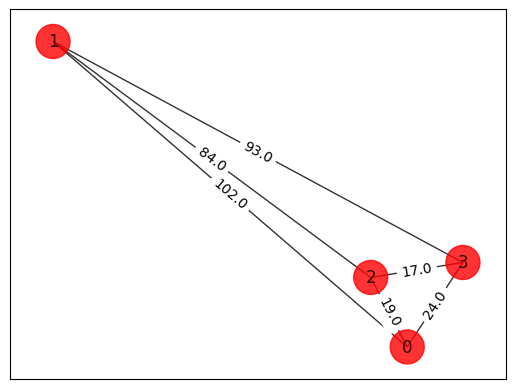

```python
# import the Traveling Salesman Problem (TSP) from
# the IBM Qiskit's Optimization Application module
from qiskit_optimization.applications import Tsp


# create a random instance of the Traveling Salesman Problem (TSP),
# with 4 nodes and a fixed pseudo-random seed
tsp = Tsp.create_random_instance(4, seed=43)

# retrieve the adjoint matrix for the graph representation of
# the instance of the Traveling Salesman Problem (TSP) previously created
adj_matrix = nx.to_numpy_array(tsp.graph)

# print the adjoint matrix for the graph representation of
# the instance of the Traveling Salesman Problem (TSP) previously created,
# as the distances (edges' weigths) between the respective nodes
print("Distances:\n", adj_matrix)

# set the color of the nodes of
# the instance of the Traveling Salesman Problem (TSP)
# previously created, with the red color
colors = ["r"] * len(tsp.graph.nodes)

# retrieve the positions of the nodes of
# the instance of the Traveling Salesman Problem (TSP)
pos = [tsp.graph.nodes[node]["pos"] for node in tsp.graph.nodes]

# draw the graph representation of
# the instance of the Traveling Salesman Problem (TSP),
# using the NetworkX library's functionalities
draw_graph(tsp.graph, colors, pos)
```

#### Converting the quadratic program to QUBO and Ising Hamiltonian

To solve this problem, we need to convert our quadratic program into a form that a quantum computer can work with. In this case we will generate an Ising Hamiltonian, which is simply a representation (i.e. model) of the energy of this particular system (i.e. problem). We can use eigensolvers to find the minimum energy of the Ising hamiltonian, which corresponds to the shortest path and the solution of our problem.

How do we get the Ising Hamiltonian? First, we convert the quadratic program to a QUBO (Quadratic Unconstrained Binary Optimization), a combinatorial optimization problem representation to then obtain an Ising Hamiltonian. The next code cell will teach you how we do this.

```python
# import the Quandratic Program to
# Quadratic Unconstrained Binary Optimization (QUBO) converter,
# from the IBM Qiskit's Optimization Convertes module
from qiskit_optimization.converters import QuadraticProgramToQubo


# convert the original optimization formulation of
# the Traveling Salesman Problem (TSP) created before,
# to a Quadratic Program, to solve it using a quantum computer
qp = tsp.to_quadratic_program()

# initialize the Quandratic Program to
# Quadratic Unconstrained Binary Optimization (QUBO) converter
qp2qubo = QuadraticProgramToQubo()

# convert the Quadratic Program formulation of
# the Traveling Salesman Problem (TSP) created before,
# to a Quadratic Unconstrained Binary Optimization (QUBO) Program,
# to solve it using a quantum computer
qubo = qp2qubo.convert(qp)

# convert the Quadratic Unconstrained Binary Optimization (QUBO)
# formulation of the Traveling Salesman Problem (TSP) created before,
# to an Ising Hamiltonian, to solve it using a quantum computer,
# retrieving the respective qubit operations
qubitOp, offset = qubo.to_ising()
```

Now it's time for you to construct a Variational Quantum Eigensolver (VQE) using the SamplingVQE in Qiskit! SamplingVQE is one of the two versions of VQE that Qiskit offers today and uses the sampler primitive optimized for diagonal Hamiltonians.

The Optimizer and Parametrized Ansatz Quantum Circuit are already given to you.

Please complete the code block below to construct your VQE using [SamplingVQE](https://qiskit.org/documentation/stubs/qiskit.algorithms.minimum_eigensolvers.SamplingVQE.html).

```
Energy: -43755.318359375
Elapsed Time (secs): 47.134970903396606
Feasible: True
Solution: [1, 3, 2, 0]
Solution Objective: 231.0
```

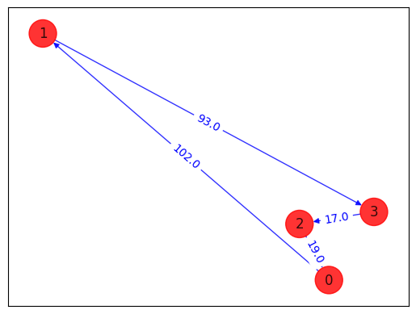

```python
# import the Sampling Variational Quantum Eigensolver (VQE) algorithm
# from the IBM Qiskit's Minimum Eigesolvers Algorithms module
from qiskit.algorithms.minimum_eigensolvers import SamplingVQE

# import the Nakanishi-Fujii-Todo (NFT) Optimizer
# from the IBM Qiskit's Optimizers Algorithms module
from qiskit.algorithms.optimizers import NFT

# import the parametrized two-local quantum circuits
# from the IBM Qiskit's Circuit Library module
from qiskit.circuit.library import TwoLocal

# import the Aer Sample from
# the IBM Qiskit's Aer Primitives module
from qiskit_aer.primitives import Sampler as AerSampler

# import the Algorithm's Global Parameters from
# the IBM Qiskit's Utilities module
from qiskit.utils import algorithm_globals


# set a fixed pseudo-random seed
# as an Algorithm's Global Parameter
algorithm_globals.random_seed = 123


# create a Nakanishi-Fujii-Todo (NFT) Optimizer instance,
# with a maximum number of 100 iterations
optimizer = NFT(maxiter=100)

# create a Parametrized Two-Local Ansatz Quantum Circuit,
# for the parametrized y-axis rotations for the qubits,
# aiming a linear quantum entanglement
ry = TwoLocal(qubitOp.num_qubits, "ry", "cz",
              reps = 2, entanglement = "linear")


####### build your code below #########

# build a Variational Quantum Eigensolver (VQE) algorithm instance,
# with the respective Aer Sample, Parametrized Two-Local Ansatz
# Quantum Circuit, and Nakanishi-Fujii-Todo (NFT) Optimizer,
# to solve the Traveling Salesman Problem (TSP) created before
vqe = SamplingVQE(sampler=AerSampler(), ansatz=ry, optimizer=optimizer)

####### build your code above #########


# compute the minimum eigenvalue for
# the Variational Quantum Eigensolver (VQE) algorithm instance
# created before to solve the Traveling Salesman Problem (TSP)
# created before, using the Qubit Operations retrieved before
result = vqe.compute_minimum_eigenvalue(qubitOp)

# print the energy values from minimum eigenvalue computed before
# from Variational Quantum Eigensolver (VQE) algorithm instance
# that solved the Traveling Salesman Problem (TSP)
print("Energy:", result.eigenvalue.real)

# print the elepsed time to compute minimum eigenvalue
# from Variational Quantum Eigensolver (VQE) algorithm instance
# that solved the Traveling Salesman Problem (TSP)
print("Elapsed Time (secs):", result.optimizer_time)


# retrieve the most likely saple from the eigenstate
# from the minimum eigenvalue computed before
# from Variational Quantum Eigensolver (VQE) algorithm instance
# that solved the Traveling Salesman Problem (TSP),
# as one the possible solutions for it
x = tsp.sample_most_likely(result.eigenstate)

# retrieve the boolean flag with respect to
# the fact that the solution achieved is feasible
# for the Quadratic Unconstrained Binary Optimization (QUBO) Program
# formulating the pretended Traveling Salesman Problem (TSP)
print("Feasible:", qubo.is_feasible(x))

# retrieves (and interprets) the solution result as a list of
# nodes' indices corresponding to the real solution
# for the pretended Traveling Salesman Problem (TSP)
z = tsp.interpret(x)

# print the list of nodes' indices
# corresponding to the real solution (nodes' sequence)
# for the pretended Traveling Salesman Problem (TSP)
print("Solution:", z)

# print solution to the objective function
# corresponding to the real solution (nodes' sequence)
# for the pretended Traveling Salesman Problem (TSP)
print("Solution Objective:", tsp.tsp_value(z, adj_matrix))

# draw the solution of the pretended Traveling Salesman Problem (TSP)
# solution, in the respective graph representation
draw_tsp_solution(tsp.graph, z, colors, pos)
```

```python
# run this cell to submit your answer

# import the grader for the coding exercise of the lab/badge 6
from qc_grader.challenges.quantum_explorers23 import grade_badge6_code

# expected result type: ( tsp: Tsp, qubo: QuadraticProgram,
#                         result: SamplingVQEResult )
grade_badge6_code(tsp, qubo, result)
```

```
Submitting your answer. Please wait...
Congratulations! 🎉 Your answer is correct.
```

#### [Ungraded] Run Variational Quantum Eigensolver (VQE) on a real device!

Run the cells below to run Variational Quantum Eigensolver (VQE) on a real device.

```python
# import the Qiskit Runtime Service, Session, and Sampler,
# from the Qiksit's IBM Runtime module
from qiskit_ibm_runtime import QiskitRuntimeService, Session, Sampler


# create a Qiskit's Runtime Service object,
# using the IBM Quantum channel
service = QiskitRuntimeService( channel="ibm_quantum" )


# retrieve the least-busy backend
# with a minimum number of qubits
# corresponding to the number of qubits
# required for the retrieved Qubit Operations
# (this step can take a while)
real_backend = service.least_busy( min_num_qubits=qubitOp.num_qubits,
                                   simulator=False )

# print the information about the best (i.e., the least-busy)
# backend with a minimum number of two qubits, and an informative
# message about the job submission on this backend
print(f"The least busy backend is {real_backend.name}!")
```

```
The least busy backend is ibm_brisbane!
```

```python
# within the context of a Session configured
# with the Qiskit's Runtime Service object,
# created before, using the IBM Quantum channel,
# and also using the backend defined before
# with Session( service=service, backend=real_backend ) as session:

    ###### add your answers from the above code cell here #######
    ###### before running this code cell itself           #######

    # build a Variational Quantum Eigensolver (VQE) algorithm instance,
    # with the respective Aer Sample, Parametrized Two-Local Ansatz
    # Quantum Circuit, and Nakanishi-Fujii-Todo (NFT) Optimizer,
    # to solve the Traveling Salesman Problem (TSP) created before
    #vqe = SamplingVQE(sampler=Sampler(), ansatz=ry, optimizer=optimizer)

    # compute the minimum eigenvalue for
    # the Variational Quantum Eigensolver (VQE) algorithm instance
    # created before to solve the Traveling Salesman Problem (TSP)
    # created before, using the Qubit Operations retrieved before
    #result = vqe.compute_minimum_eigenvalue(qubitOp)


# compute the minimum eigenvalue for
# the Variational Quantum Eigensolver (VQE) algorithm instance
# created before to solve the Traveling Salesman Problem (TSP)
# created before, using the Qubit Operations retrieved before
#result = vqe.compute_minimum_eigenvalue(qubitOp)

# print the energy values from minimum eigenvalue computed before
# from Variational Quantum Eigensolver (VQE) algorithm instance
# that solved the Traveling Salesman Problem (TSP)
#print("Energy:", result.eigenvalue.real)

# print the elepsed time to compute minimum eigenvalue
# from Variational Quantum Eigensolver (VQE) algorithm instance
# that solved the Traveling Salesman Problem (TSP)
#print("Elapsed Time (secs):", result.optimizer_time)


# retrieve the most likely saple from the eigenstate
# from the minimum eigenvalue computed before
# from Variational Quantum Eigensolver (VQE) algorithm instance
# that solved the Traveling Salesman Problem (TSP),
# as one the possible solutions for it
#x = tsp.sample_most_likely(result.eigenstate)

# retrieve the boolean flag with respect to
# the fact that the solution achieved is feasible
# for the Quadratic Unconstrained Binary Optimization (QUBO) Program
# formulating the pretended Traveling Salesman Problem (TSP)
#print("Feasible:", qubo.is_feasible(x))

# retrieves (and interprets) the solution result as a list of
# nodes' indices corresponding to the real solution
# for the pretended Traveling Salesman Problem (TSP)
#z = tsp.interpret(x)

# print the list of nodes' indices
# corresponding to the real solution (nodes' sequence)
# for the pretended Traveling Salesman Problem (TSP)
#print("Solution:", z)

# print solution to the objective function
# corresponding to the real solution (nodes' sequence)
# for the pretended Traveling Salesman Problem (TSP)
#print("Solution Objective:", tsp.tsp_value(z, adj_matrix))

# draw the solution of the pretended Traveling Salesman Problem (TSP)
# solution, in the respective graph representation
#draw_tsp_solution(tsp.graph, z, colors, pos)
```

### Extra Credit Multiple Choice Questions

These questions are more advanced.

**Extra Credit Question A: Which of the following conversion is NOT necessary for a quantum computer to solve a quadratic program?**

1. Quadratic to linear function conversion.
2. Quadratic program to QUBO conversion.
3. Inequality constraints to equality constraints conversion.
4. QUBO to Ising Hamiltonian conversion.

```python
# build your code here
answer13 = [1]
```

```python
# run this cell to submit your answer

# import the grader for the exercise 13 of the lab/badge 6
from qc_grader.challenges.quantum_explorers23 import grade_badge6_ex13

# expected result type: List
grade_badge6_ex13(answer13)
```

```
Submitting your answer. Please wait...
Thank you for submitting your answer. Your answer has been recorded and, if correct, will count towards your final score.
```

**Extra Credit Question B: Which of the following circuits is a 4-qubit mixing unitary in a variational algorithm QAOA?**

1. Circuit A.
2. Circuit B.
3. Circuit C.
4. Circuit D.

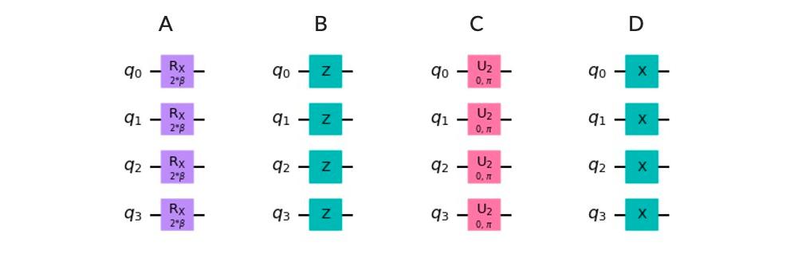

```python
# build your code here
answer14 = [1]
```

```python
# run this cell to submit your answer

# import the grader for the exercise 14 of the lab/badge 6
from qc_grader.challenges.quantum_explorers23 import grade_badge6_ex14

# expected result type: List
grade_badge6_ex14(answer14)
```

```
Submitting your answer. Please wait...
Thank you for submitting your answer. Your answer has been recorded and, if correct, will count towards your final score.
```

**Extra Credit Question C: What combination of words will complete the explanation of the QAOA algorithm below most accurately?**

1. a) Optimal, b) Objective Function, c) Z Basis, d) Probability Distribution.
2. a) Expectation, b) Objective Function, c) Superposition, d) Bit String.
3. a) Optimal, b) Hamiltonian, c) H Basis, d) Probability Distribution.
4. a) Expectation, b) Hamiltonian, c) Z Basis, d) Bit String.

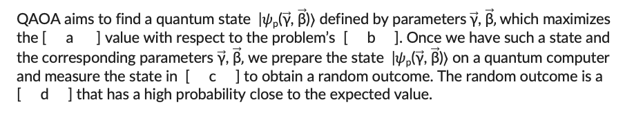

```python
# build your code here
answer15 = [4]
```

```python
# run this cell to submit your answer

# import the grader for the exercise 15 of the lab/badge 6
from qc_grader.challenges.quantum_explorers23 import grade_badge6_ex15

# expected result type: List
grade_badge6_ex15(answer15)
```

```
Submitting your answer. Please wait...
Thank you for submitting your answer. Your answer has been recorded and, if correct, will count towards your final score.
```

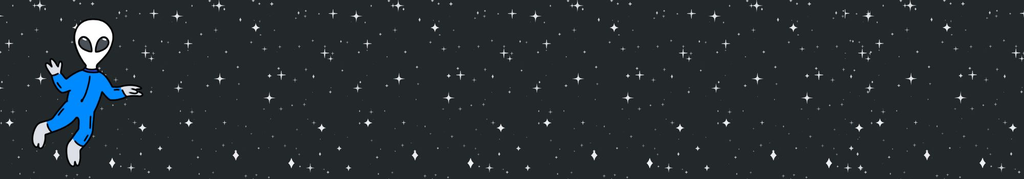

## Unlock Your Badge

Run the cell below to see whether you've passed the quiz. Passing score is 80%. If you have successfully passed, a password will be revealed. (Note: since there are extra credit questions, you may get over 100%!)

Please do not change the code in this cell.

```python
# run this cell to check whether you have passed

# import the grader for the badge 6 of
# the IBM Qiskit's Quantum Explorers 2023-2024
from qc_grader.challenges.quantum_explorers23 import grade_badge6_score

# grade the score of the quiz of the lab for the badge 6
grade_badge6_score("en")
```

```
Submitting your answer. Please wait...

Congratulations, Expert Navigator 🎉 🚀! You've passed with a percentage of 120.0%

You have successfully navigated through the asteroid field.

The password you are looking for is Rockyroad# inclusive of the #.
```

Have you passed? Congratulations!

Here's what you need to do to unlock your Expert Navigator achievement:

1. Download the Expert Navigator badge image from **[this link](https://ibm.box.com/s/r44tpmypaqffbrrpqrkqoxxiyt24682p)**. The link is password protected; enter the password revealed from the above cell.
2. Post the image to the **[#level-up channel on Discord](https://discord.com/channels/979714492533440533/1096012934829854720)** to get your shiny new Discord label! Please allow up to 5 business days for the badge label to show up under your Discord handle before querying an admin.

Made with ❤ by Rúben André Barreiro (and adapted from IBM Quantum).